# Homework YY

Ale Murillo Umanzor

3/10/26

## Instructions

Answer the following questions and complete the exercises in RMarkdown. Please embed all of your code and push your final work to your repository. Your final lab report should be organized, clean, and run free from errors. Remember, you must remove the `#` for the included code chunks to run. Be sure to add your name to the author header above. For any included plots, make sure they are clearly labeled. You are free to use any plot type that you feel best communicates the results of your analysis.

Make sure to use the formatting conventions of RMarkdown to make your report neat and clean!

### Install Biostrings

```r
if (!requireNamespace("BiocManager", quietly = TRUE))
  install.packages("BiocManager")

BiocManager::install("Biostrings")
```

## Load the libraries

```r
library(tidyverse)
library(janitor)
library(dplyr)
library(readr)
library(Biostrings)
```

```r
options(scipen = 999)
```

## Background

A patient has been admitted to the hospital with a severe and rapidly progressing bacterial infection of unknown origin. Standard clinical cultures have been inconclusive. As part of the diagnostic workup, RNA was extracted directly from the patient’s tissue sample and submitted for RNA sequencing (RNA-seq). From this sequencing data, you have successfully assembled the complete coding sequence of a gene expressed by the infecting bacterium. You will use BLAST, a tool used in real clinical and research microbiology labs, to compare this unknown sequence against all known biological sequences in the NCBI database.

**SKIP #1**

**1. Read the “gene of interest” sequence from the `goi_01.txt` file into R using the Biostrings package. Store this in an object called `query_seq`.What type sequence is this? (DNA, RNA or Protien)**

**2.Perform a blastx search using `goi_01.txt` as the query and the “nr_cluster_seq” database. Download the cluter table results in CSV format, change the name to “goi_01_blastx.csv” in the homework folder. Read the csv file into R and clean the column names. Save the cleaned data frame as goi_01_blastx.**

```r
goi_01_blastx <- read_csv("data/goi_01_blastx.csv") %>%
  clean_names()
goi_01_blastx
```

```
## # A tibble: 100 × 10
##    cluster_composition         cluster_ancestor representative_seque…¹ max_score
##    <chr>                       <chr>            <chr>                      <dbl>
##  1 8 member(s) 4 organism(s)   enterobacteria   minor capsid protein,…       215
##  2 11 member(s) 6 organism(s)  enterobacteria   minor capsid protein …       211
##  3 91 member(s) 31 organism(s) root             minor capsid protein …       210
##  4 61 member(s) 17 organism(s) enterobacteria   minor capsid protein …       196
##  5 4 member(s) 3 organism(s)   bacteria         minor capsid protein,…       194
##  6 1 member(s) 1 organism(s)   CDC Enteric Gro… hypothetical protein …       192
##  7 1 member(s) 1 organism(s)   enterobacteria   minor capsid protein …       192
##  8 1 member(s) 1 organism(s)   enterobacteria   minor capsid protein …       190
##  9 3 member(s) 1 organism(s)   E. coli          minor capsid protein …       185
## 10 7 member(s) 4 organism(s)   enterobacteria   minor capsid protein …       184
## # ℹ 90 more rows
## # ℹ abbreviated name: ¹representative_sequence
## # ℹ 6 more variables: total_score <dbl>, query_cover <chr>, e_value <dbl>,
## #   per_ident <dbl>, acc_len <dbl>, accession <chr>
```

```r
names(goi_01_blastx)
```

```
##  [1] "cluster_composition"     "cluster_ancestor"
##  [3] "representative_sequence" "max_score"
##  [5] "total_score"             "query_cover"
##  [7] "e_value"                 "per_ident"
##  [9] "acc_len"                 "accession"
```

**3.Display the top 10 blastx hits, based on e_value, for this blastx search? (Include the Scientific Name, Cluster Anscestor, Cluster Representative Sequence, Max Score, Query Cover, E value and Percent Identity)**

```r
goi_01_blastx %>%
  arrange(e_value) %>%
  slice_head(n = 10) %>%
  select(cluster_ancestor,
         representative_sequence,
         max_score,
         query_cover,
         e_value,
         per_ident)
```

```
## # A tibble: 10 × 6
##    cluster_ancestor     representative_sequence    max_score query_cover e_value
##    <chr>                <chr>                          <dbl> <chr>         <dbl>
##  1 enterobacteria       minor capsid protein, par…       215 81%         6  e-70
##  2 enterobacteria       minor capsid protein [Ent…       211 99%         4  e-68
##  3 root                 minor capsid protein [Esc…       210 99%         9  e-68
##  4 enterobacteria       minor capsid protein [Sal…       196 99%         3  e-62
##  5 bacteria             minor capsid protein, par…       194 74%         7  e-62
##  6 CDC Enteric Group 75 hypothetical protein [Ent…       192 99%         1  e-60
##  7 enterobacteria       minor capsid protein [But…       192 99%         1  e-60
##  8 enterobacteria       minor capsid protein [Esc…       190 99%         9  e-60
##  9 E. coli              minor capsid protein [Esc…       185 99%         1  e-57
## 10 enterobacteria       minor capsid protein [Ent…       184 99%         3  e-57
## # ℹ 1 more variable: per_ident <dbl>
```

**4. create a plot that shows the different in percent identity for each Scientific Name of the top 10 blastx hits. Make sure to label your axes and give your plot a title.**

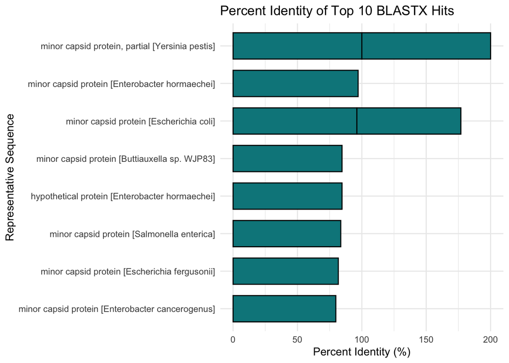

```r
goi_01_blastx %>%
  arrange(e_value) %>%
  slice_head(n = 10) %>%
  ggplot(aes(x = reorder(representative_sequence, per_ident), y = per_ident)) +
  geom_col(fill = "turquoise4", color = "black", width = 0.7) +
  coord_flip() +
  labs(
    title = "Percent Identity of Top 10 BLASTX Hits",
    x = "Representative Sequence",
    y = "Percent Identity (%)"
  ) +
  theme_minimal()
```

**5 Perform a blastn search using `goi_01.txt` as the query and the “core_nt” database. Download the alignment description in CSV format, change the name to “goi_01_blastn.csv” in the homework folder. Read the csv file into R and clean the column names. Save the cleaned data frame as goi_01_blastn.**

```r
goi_01_blastn <- read_csv("data/goi_01_blastn.csv") %>%
  clean_names()
goi_01_blastn
```

```
## # A tibble: 50 × 9
##    description         scientific_name max_score total_score query_cover e_value
##    <chr>               <chr>               <dbl>       <dbl> <chr>         <dbl>
##  1 Yersinia pestis st… Yersinia pestis       688         688 99%               0
##  2 Yersinia pestis st… Yersinia pestis       688         688 100%              0
##  3 Yersinia pestis st… Yersinia pestis       688         688 99%               0
##  4 Yersinia pestis st… Yersinia pestis       688         688 100%              0
##  5 Yersinia pestis st… Yersinia pestis       688         688 99%               0
##  6 Yersinia pestis st… Yersinia pestis       688         688 99%               0
##  7 Yersinia pestis st… Yersinia pestis       688         688 99%               0
##  8 Yersinia pestis 37… Yersinia pesti…       688         688 100%              0
##  9 Yersinia pestis st… Yersinia pestis       688         688 99%               0
## 10 Yersinia pestis st… Yersinia pestis       688         688 99%               0
## # ℹ 40 more rows
## # ℹ 3 more variables: per_ident <dbl>, acc_len <dbl>, accession <chr>
```

```r
names(goi_01_blastn)
```

```
## [1] "description"     "scientific_name" "max_score"       "total_score"
## [5] "query_cover"     "e_value"         "per_ident"       "acc_len"
## [9] "accession"
```

**6. What was the top blastn hit, based on e_value, for this blastn search? (Include the Cluster Ancestor, Cluster Representative Sequence, Max Score, Query Cover, E value, Percent Identity and Accession Link)**

```r
goi_01_blastn %>%
  arrange(e_value) %>%
  select(description,
         scientific_name,
         max_score,
         query_cover,
         e_value,
         per_ident,
         accession) %>%
head(1)
```

```
## # A tibble: 1 × 7
##   description  scientific_name max_score query_cover e_value per_ident accession
##   <chr>        <chr>               <dbl> <chr>         <dbl>     <dbl> <chr>
## 1 Yersinia pe… Yersinia pestis       688 99%               0      99.2 "=HYPERL…
```

**7. Based on the blastx and blastn results, what do you think this gene is and what bacteria do you think it came from?** The BLASTX and BLASTN results show that the sequence most closely matches genes from Yersinia pestis. The gene appears to be located on the pMT1 plasmid, which contains virulence-related genes important for infection and transmission in this bacterium.

**8. For the top blastn hit, click on the accession link for this bacteria and download the coding sequences as a FASTA Protein file. Read the fasta file into R using the Biostrings package and store it in an object called `goi_blastn_hit`.**

```r
goi_blastn_hit <- readAAStringSet("data/goi_01.fasta")
```

```r
goi_blastn_hit
```

```
## AAStringSet object of length 1:
##     width seq                                               names
## [1]   385 GTCTTTATTGAAGCATTTGCGAG...TTGCGGGCTATTTGTTGAATTAA unknown sequence
```

**9. From the same organism, identify 5 other annotated genes? Do these genes suggest about the biology or virulence of this bacterium?** *Annotated genes can be found in the “CDS” section of the GenBank file. You can also find genes by going to summary page for the organism and looking at the “View annotated genes” section.*

```r
genes <- read_tsv("data/genes.tsv")
genes <- genes[!is.na(genes$Symbol), ]
genes[1:5, c("Name", "Symbol")]
```

```
## # A tibble: 5 × 2
##   Name                                           Symbol
##   <chr>                                          <chr>
## 1 chromosomal replication initiator protein DnaA dnaA
## 2 DNA polymerase III subunit beta                dnaN
## 3 DNA replication/repair protein RecF            recF
## 4 DNA topoisomerase (ATP-hydrolyzing) subunit B  gyrB
## 5 sugar-phosphatase                              yidA
```

Five annotated genes from Yersinia pestis include dnaA, dnaN, recF, gyrB, and yidA. These genes are involved in DNA replication, repair, and cell function, which help the bacterium grow and survive in its host. **10. Now that you have an idea of this bacteria’s identity, what illness/disease do you think the patient has? What is the historical or public health significance of this disease? Based on the gene you identified, what role might this gene play in pathogenicity?** The patient likely has plague, caused by Yersinia pestis. This disease is historically significant because it caused the Black Death, one of the deadliest pandemics in history. The gene identified may help the bacterium survive in the host and contribute to its ability to cause infection.

## Knit and Upload

Please knit your work as an .html file and upload to Canvas. Homework is due before the start of the next lab. No late work is accepted. Make sure to use the formatting conventions of RMarkdown to make your report neat and clean!